# Train and test baseline models to predict MB subgroups

# Visualize Kappa and accuracy results

### Gather data

The variable `baseline_list` is a list of lists. The first level of lists correspond to different repeats using different training/testing sets. Within each repeat, there are list elements corresponding to particular model results (e.g., `ktsp_weighted` or `lasso`) as well as metadata about the repeat (e.g., the seed used for to determine training/testing sets). To create a data frame for plotting, we need to gather modeling metrics (Kappa and Balanced Accuracy) from each model across all the repeats.

```r
plot_df <- baseline_list |>
  purrr::map(return_model_metrics,
             model_types = model_types,
             metadata_df = bulk_metadata_df,
             labels = mb_subgroups,
             platforms = c("Array", "RNA-seq")) |>
  purrr::list_rbind(names_to = "repeat_index") |>
  dplyr::mutate(model_type = dplyr::case_match(model_type,
                                               "ktsp_unweighted" ~ "kTSP (unw)",
                                               "ktsp_weighted" ~ "kTSP (w)",
                                               "rf_unweighted" ~ "RF (unw)",
                                               "rf_weighted" ~ "RF (w)",
                                               "mm2s" ~ "MM2S",
                                               "lasso" ~ "LASSO"))

readr::write_tsv(x = plot_df,
                 file = baseline_plot_df_filepath)
```

### Kappa tables

Kappa measures how often our predicted subgroups agree with the true subgroups, accounting for the chance of random agreement (necessary when subgroups are imbalanced). Kappa is an overall measure that applies to an entire set of predictions across subgroups. Values of Kappa closer to 1 indicate higher agreement, and values closer to 0 indicate random assignment.

$$\kappa = \frac{p_o - p_e}{1 - p_e}$$

where $p_o$ is the observed proportion of agreement and $p_e$ is the expected proportion of chance agreement.

The following table summarizes Kappa values stratified by platform (Array or RNA-seq) and model type by showing the median Kappa value.

```r
plot_df |>
  dplyr::filter(metric == "Kappa") |>
  dplyr::group_by(platform, model_type) |>
  dplyr::summarize(median_kappa = median(value),
                   .groups = "drop") |>
  tidyr::pivot_wider(names_from = platform,
                     values_from = median_kappa) |>
  knitr::kable(caption = "Median Kappa values (by platform)")
```

Median Kappa values (by platform)

| model_type | Array | RNA-seq |
| --- | --- | --- |
| LASSO | 0.9436365 | 0.9419247 |
| MM2S | 0.8403620 | 0.9193274 |
| RF (unw) | 0.9385661 | 0.9149005 |
| RF (w) | 0.9560241 | 0.9550649 |
| kTSP (unw) | 0.9597618 | 0.9377026 |
| kTSP (w) | 0.9573904 | 0.9072461 |

- Models perform slightly better on Array test data (mid-.90s) than RNA-seq test data (low-.90s) (except for MM2S).
- kTSP (w) and kTSP (unw) show no difference in performance in Array test data (more Array data in training set), but kTSP (unw) outperformed kTSP (w) in RNA-seq test data (against expectation)
- The reverse is true for RF models, with RF (w) outperforming RF (unw) for both Array and RNA-seq test data
- In weighted models, RF outperformed kTSP in RNA-seq, while the unweighted kTSP outperformed RF in both platforms
- MM2S showed better test performance in RNA-seq data despite the original model being trained on Array

### Plot Kappa

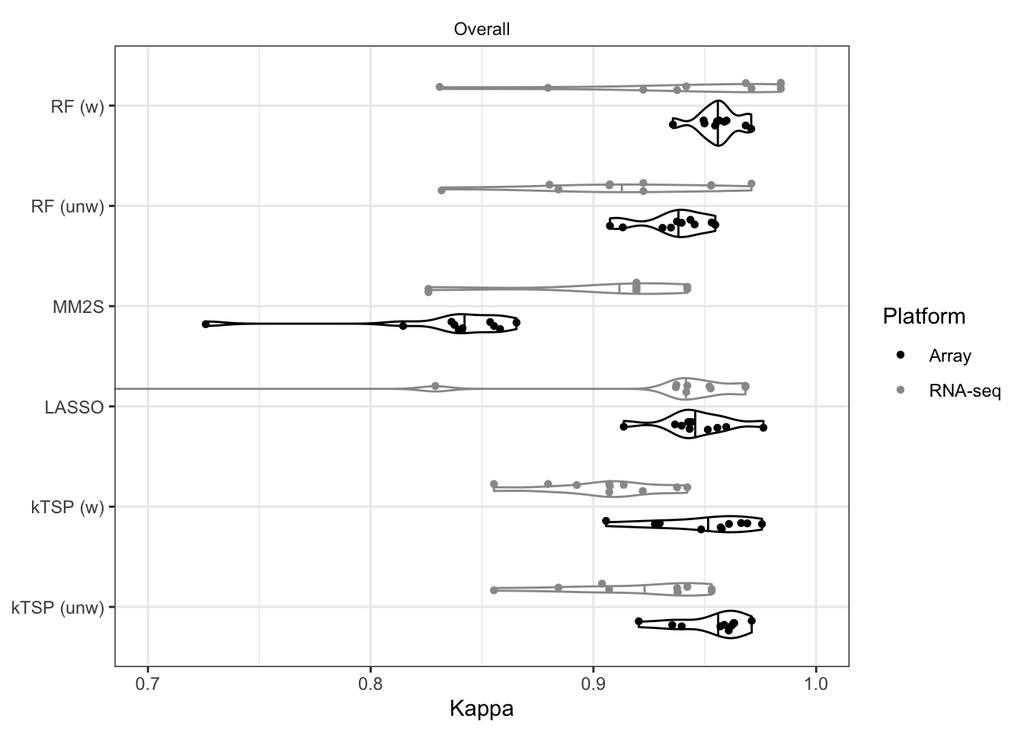

```r
set.seed(params$seed)

baseline_kappa_plot <- plot_df |>
  dplyr::filter(metric == "Kappa") |>
  ggplot2::ggplot(ggplot2::aes(x = value,
                               y = model_type,
                               color = platform)) +
  ggplot2::geom_violin(draw_quantiles = 0.5,
                       position = ggplot2::position_dodge(0.7),
                       show.legend = FALSE) +
  ggplot2::geom_point(shape = 16,
                      position = ggplot2::position_jitterdodge(jitter.width = 0.1,
                                                               jitter.height = 0)) +
  ggplot2::coord_cartesian(xlim = c(0.7,1)) +
  ggplot2::facet_wrap(~ subgroup,
                      ncol = 1) +
  ggplot2::labs(x = "Kappa",
                y = NULL,
                color = "Platform") +
  ggplot2::scale_color_manual(values = platform_colors) +
  ggplot2::scale_fill_manual(values = c("#FFFFFF", "#FFFFFF")) +
  ggplot2::theme_bw() +
  ggplot2::theme(strip.background = ggplot2::element_blank())

ggplot2::ggsave(filename = baseline_kappa_plot_filepath,
                plot = baseline_kappa_plot,
                height = 7,
                width = 7)

baseline_kappa_plot
```

To aid in visualization, the following data points were excluded from the previous plot. Later we explore this excluded data point in more detail.

```r
plot_df |>
  dplyr::filter(metric == "Kappa",
                value < 0.7)
```

| repeat_index | model_type | platform | study | which_studies | official_model | total_samples | subgroup | subgroup_samples | metric | value |
| --- | --- | --- | --- | --- | --- | --- | --- | --- | --- | --- |
| 9 | LASSO | RNA-seq | Combined | GSE164677 | FALSE | 59 | Overall | 59 | Kappa | 0.05160745 |

### Accuracy tables

Balanced accuracy is the average sensitivity and specificity of a model and is measured per subgroup.

$$\text{Balanced Accuracy} =
\frac{Sensitivity + Specificity}{2}$$

where

$$\text{Sensitivity} = \frac{TP}{TP + FN}
\text{ and Specificity} = \frac{TN}{TN + FP}$$

for true and false positive and negative predictions.

#### Array test data

```r
plot_df |>
  dplyr::filter(metric == "Balanced Accuracy",
                platform == "Array") |>
  dplyr::group_by(model_type, subgroup) |>
  dplyr::summarize(median_accuracy = median(value),
                   .groups = "drop") |>
  tidyr::pivot_wider(names_from = subgroup,
                     values_from = median_accuracy) |>
knitr::kable(caption = "Median Balanced Accuracy values")
```

Median Balanced Accuracy values

| model_type | G3 | G4 | SHH | WNT |
| --- | --- | --- | --- | --- |
| LASSO | 0.9513225 | 0.9658041 | 0.9936381 | 0.9916424 |
| MM2S | 0.7935768 | 0.9340924 | 0.9547034 | 0.9683444 |
| RF (unw) | 0.9399975 | 0.9574562 | 0.9974677 | 0.9923780 |
| RF (w) | 0.9587904 | 0.9733609 | 0.9971629 | 0.9922256 |
| kTSP (unw) | 0.9556872 | 0.9738730 | 0.9970210 | 0.9926966 |
| kTSP (w) | 0.9647111 | 0.9701812 | 0.9967045 | 0.9898236 |

#### RNA-seq test data

```r
plot_df |>
  dplyr::filter(metric == "Balanced Accuracy",
                platform == "RNA-seq") |>
  dplyr::group_by(model_type, subgroup) |>
  dplyr::summarize(median_accuracy = median(value),
                   .groups = "drop") |>
  tidyr::pivot_wider(names_from = subgroup,
                     values_from = median_accuracy) |>
  knitr::kable(caption = "Median Balanced Accuracy values")
```

Median Balanced Accuracy values

| model_type | G3 | G4 | SHH | WNT |
| --- | --- | --- | --- | --- |
| LASSO | 0.9878049 | 0.9687500 | 0.9791667 | 1.0000000 |
| MM2S | 0.9223986 | 0.9683067 | 0.9565217 | 0.9882353 |
| RF (unw) | 0.9695122 | 0.9599359 | 0.9791667 | 0.9970930 |
| RF (w) | 0.9817073 | 0.9781250 | 0.9791667 | 1.0000000 |
| kTSP (unw) | 0.9756098 | 0.9635417 | 0.9800000 | 1.0000000 |
| kTSP (w) | 0.9695122 | 0.9583333 | 0.9687500 | 0.9970930 |

The following plot illustrates the differences observed between model types in G3 subgroup Balanced Accuracy.

### Plot accuracy (G3 only)

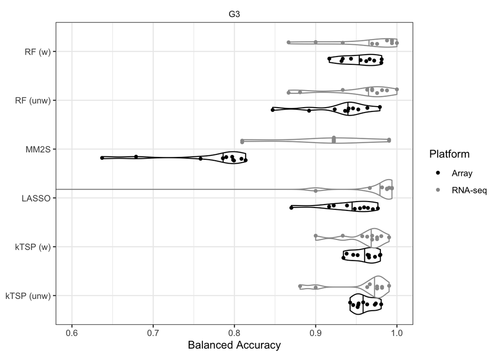

```r
set.seed(params$seed)

baseline_accuracy_plot <- plot_df |>
  dplyr::filter(metric == "Balanced Accuracy",
                subgroup %in% c("G3")) |>
  ggplot2::ggplot(ggplot2::aes(x = value,
                               y = model_type,
                               color = platform)) +
  ggplot2::geom_violin(draw_quantiles = 0.5,
                       show.legend = FALSE,
                       position = ggplot2::position_dodge(0.7)) +
  ggplot2::geom_point(shape = 16,
                      position = ggplot2::position_jitterdodge(jitter.width = 0.1,
                                                               jitter.height = 0)) +
  ggplot2::facet_wrap(~ subgroup,
                      ncol = 1) +
  ggplot2::coord_cartesian(xlim = c(0.6,1)) +
  ggplot2::labs(x = "Balanced Accuracy",
                y = NULL,
                color = "Platform") +
  ggplot2::scale_fill_manual(values = c("#FFFFFF", "#FFFFFF")) +
  ggplot2::scale_color_manual(values = platform_colors) +
  ggplot2::theme_bw() +
  ggplot2::theme(strip.background = ggplot2::element_blank())

ggplot2::ggsave(filename = baseline_accuracy_plot_filepath,
                plot = baseline_kappa_plot,
                height = 7,
                width = 7)

baseline_accuracy_plot
```

To aid in visualization, the following data points were excluded from the previous plot. Later we explore this excluded data point in more detail.

```r
plot_df |>
  dplyr::filter(metric == "Balanced Accuracy",
                subgroup %in% c("G3"),
                value < 0.6)
```

| repeat_index | model_type | platform | study | which_studies | official_model | total_samples | subgroup | subgroup_samples | metric | value |
| --- | --- | --- | --- | --- | --- | --- | --- | --- | --- | --- |
| 9 | LASSO | RNA-seq | Combined | GSE164677 | FALSE | 59 | G3 | 15 | Balanced Accuracy | 0.5333333 |

### Excluded data point

What’s up with the LASSO model on RNA-seq data from repeat 9? Note, this analysis will be specific to the particular data sets and parameters used in the original creation of this notebook.

```r
lasso_rnaseq_repeat_9_df <- baseline_list[[9]]$test_metadata |>
  dplyr::filter(platform == "RNA-seq") |>
  dplyr::left_join(baseline_list[[9]]$lasso$test_results$predicted_labels_df,
                   by = "sample_accession")

calculate_confusion_matrix(predicted_labels = lasso_rnaseq_repeat_9_df$predicted_labels,
                           true_labels = lasso_rnaseq_repeat_9_df$subgroup,
                           labels = mb_subgroups)$table
```

```
##           Reference
## Prediction G3 G4 SHH WNT
##        G3   1  0   0   0
##        G4   0  1   0   0
##        SHH 14 18  19   6
##        WNT  0  0   0   0
```

For this repeat (only), the model predicts almost all samples to be SHH!

### kTSP (w) binary rules plot

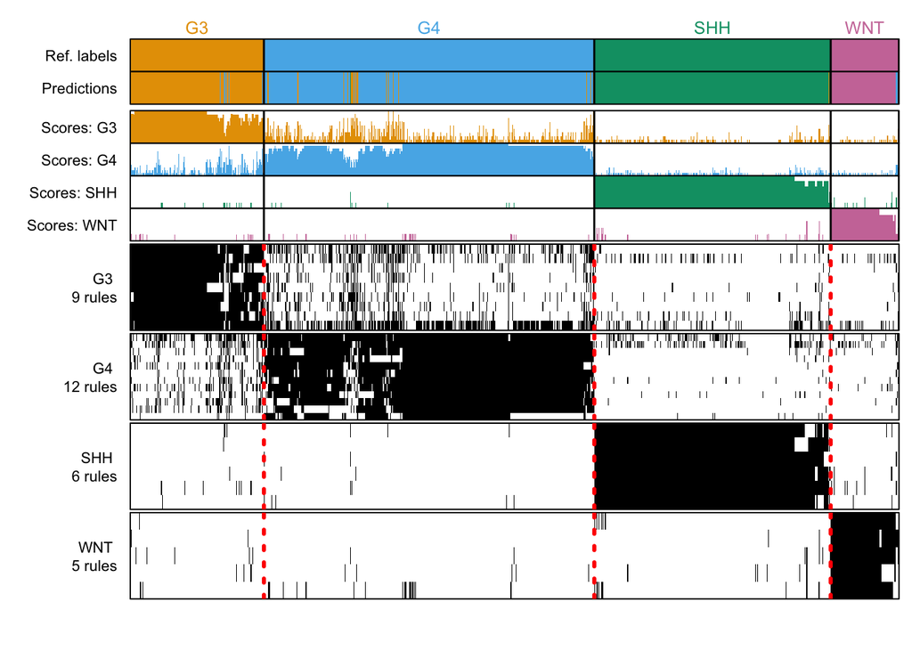

```r
official_model <- baseline_list |>
  purrr::map_lgl("official_model") |>
  which()
official_train_test_seed <- baseline_list[[official_model]]$train_test_seed
official_ktsp_model <- baseline_list[[official_model]][["ktsp_weighted"]]$classifier
official_ktsp_test_results <- baseline_list[[official_model]][["ktsp_weighted"]]$test_results$model_output


train_test_samples_list <- get_train_test_samples(genex_df = bulk_genex_df,
                                                  metadata_df = bulk_metadata_df,
                                                  train_test_seed = official_train_test_seed,
                                                  proportion_of_studies_train = 0.5)

# confirm it's the same test samples in the same order
if (any(train_test_samples_list$test != row.names(official_ktsp_test_results))) {

  stop("Testing sets do not match!")

} else { # use train_test_samples_list and classifier to visualize binary rules

  genex_df_test <- bulk_genex_df |>
    dplyr::select(train_test_samples_list$test)
  metadata_df_test <- bulk_metadata_df |>
    dplyr::filter(sample_accession %in% train_test_samples_list$test)

  test_data_object <- multiclassPairs::ReadData(Data = genex_df_test,
                                                Labels = metadata_df_test$subgroup,
                                                Platform = metadata_df_test$platform,
                                                verbose = FALSE)

  # The plot_binary_TSP() output cannot be saved to a variable directly, but
  # saving the plot as a function call makes it available to call again later
  # Source: https://stackoverflow.com/a/46961131
  binary_TSP_plot <- \() {multiclassPairs::plot_binary_TSP(Data = test_data_object,
                                                           classifier = official_ktsp_model,
                                                           prediction = official_ktsp_test_results,
                                                           classes = mb_subgroups,
                                                           show_rule_name = FALSE,
                                                           show_platform = FALSE,
                                                           ref_col = subgroup_colors,
                                                           pred_col = subgroup_colors,
                                                           legend = FALSE,
                                                           anno_height = 0.05,
                                                           score_height = 0.05,
                                                           margin = c(0, 5, 0, 0.5))}

  ggplot2::ggsave(filename = baseline_binary_TSP_plot_filepath,
                  plot = binary_TSP_plot(),
                  width = 7,
                  height = 7)

}
```

### kTSP (w) confusion matrix

```r
baseline_list[[official_model]][["ktsp_weighted"]]$cm
```

```
## Confusion Matrix and Statistics
##
##           Reference
## Prediction  G3  G4 SHH WNT
##        G3  177  23   1   1
##        G4    5 426   1   2
##        SHH   0   1 320   0
##        WNT   0   0   0  90
##
## Overall Statistics
##
##                Accuracy : 0.9675
##                  95% CI : (0.9549, 0.9774)
##     No Information Rate : 0.4298
##     P-Value [Acc > NIR] : < 2.2e-16
##
##                   Kappa : 0.9527
##
##  Mcnemar's Test P-Value : NA
##
## Statistics by Class:
##
##                      Class: G3 Class: G4 Class: SHH Class: WNT
## Sensitivity             0.9725    0.9467     0.9938    0.96774
## Specificity             0.9711    0.9866     0.9986    1.00000
## Pos Pred Value          0.8762    0.9816     0.9969    1.00000
## Neg Pred Value          0.9941    0.9608     0.9972    0.99687
## Precision               0.8762    0.9816     0.9969    1.00000
## Recall                  0.9725    0.9467     0.9938    0.96774
## F1                      0.9219    0.9638     0.9953    0.98361
## Prevalence              0.1738    0.4298     0.3075    0.08883
## Detection Rate          0.1691    0.4069     0.3056    0.08596
## Detection Prevalence    0.1929    0.4145     0.3066    0.08596
## Balanced Accuracy       0.9718    0.9666     0.9962    0.98387
```

# Baseline figure

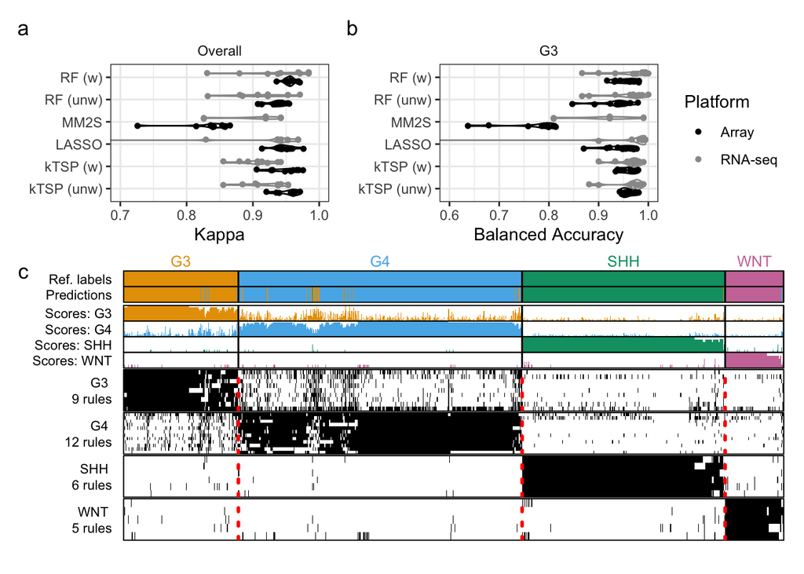

```r
panel_a_b <- baseline_kappa_plot + baseline_accuracy_plot +
  patchwork::plot_layout(guides = "collect")
panel_c <- patchwork::wrap_elements(full = ~ binary_TSP_plot())

figure_plot <- panel_a_b / panel_c +
  patchwork::plot_annotation(tag_levels = 'a') +
  patchwork::plot_layout(nrow = 2,
                         heights = c(1,2))

ggplot2::ggsave(filename = baseline_figure_filepath,
                plot = figure_plot,
                width = 7.5,
                height = 6)

figure_plot
```